# W3cubDocs

###### d3.**geoMollweide**() · [Source](https://github.com/d3/d3-geo-projection/blob/main/src/mollweide.js), [Examples](https://observablehq.com/@d3/mollweide) d3.**geoMollweideRaw**

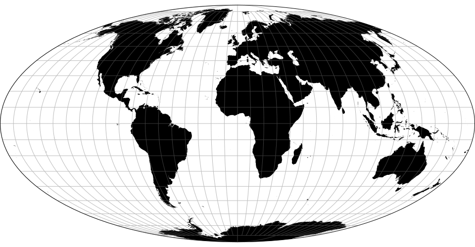

The equal-area, pseudocylindrical Mollweide projection. The oblique aspect is known as the [Atlantis projection](https://observablehq.com/@d3/atlantis). Goode’s interrupted Mollweide is also widely known.

###### d3.**geoMtFlatPolarParabolic**() · [Source](https://github.com/d3/d3-geo-projection/blob/main/src/mtFlatPolarParabolic.js), [Examples](https://observablehq.com/@d3/flat-polar-parabolic) d3.**geoMtFlatPolarParabolicRaw**

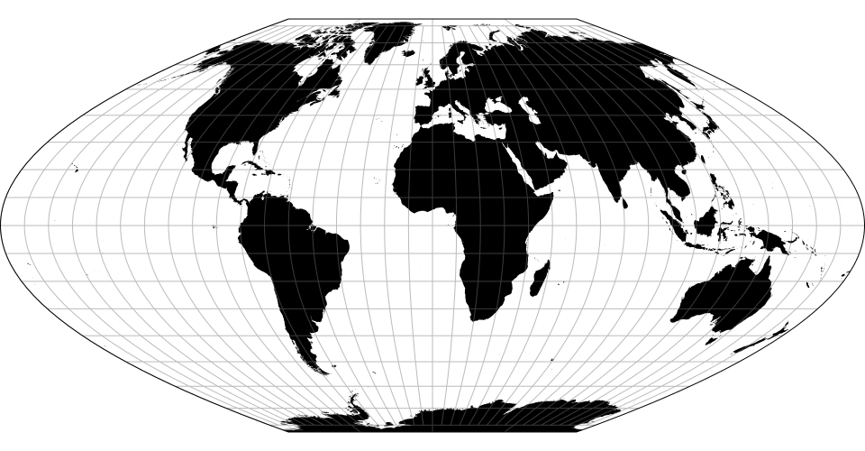

The McBryde–Thomas flat-polar parabolic pseudocylindrical equal-area projection.

###### d3.**geoMtFlatPolarQuartic**() · [Source](https://github.com/d3/d3-geo-projection/blob/main/src/mtFlatPolarQuartic.js), [Examples](https://observablehq.com/@d3/flat-polar-quartic) d3.**geoMtFlatPolarQuarticRaw**

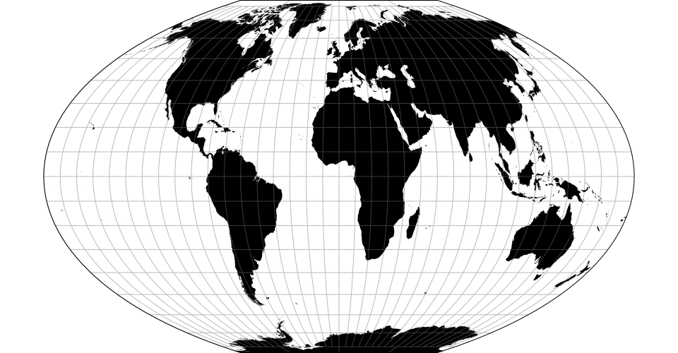

The McBryde–Thomas flat-polar quartic pseudocylindrical equal-area projection.

###### d3.**geoMtFlatPolarSinusoidal**() · [Source](https://github.com/d3/d3-geo-projection/blob/main/src/mtFlatPolarSinusoidal.js), [Examples](https://observablehq.com/@d3/flat-polar-sinusoidal) d3.**geoMtFlatPolarSinusoidalRaw**

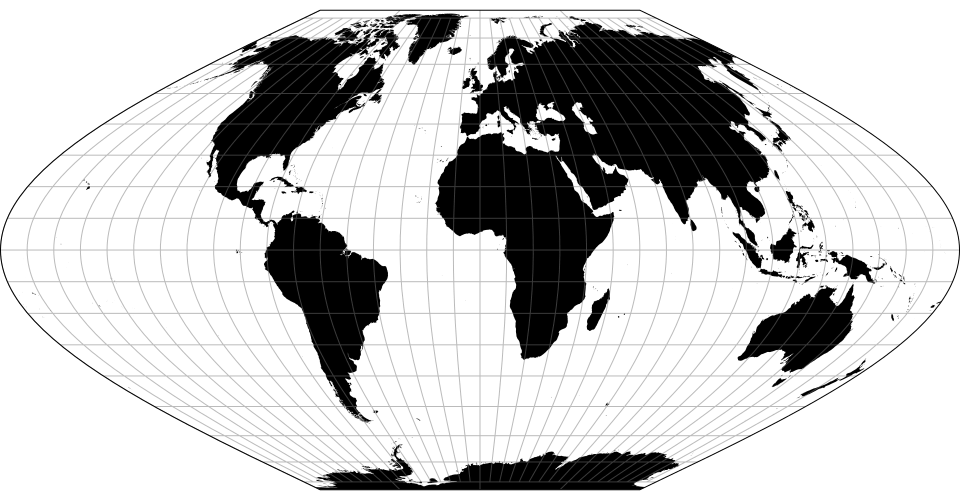

The McBryde–Thomas flat-polar sinusoidal equal-area projection.

###### d3.**geoNaturalEarth1**() · [Source](https://github.com/d3/d3-geo/blob/main/src/projection/naturalEarth1.js) [[d3-geo]](https://github.com/d3/d3-geo/blob/main/README.md#geoNaturalEarth1), [Examples](https://observablehq.com/@d3/natural-earth) d3.**geoNaturalEarth1Raw**

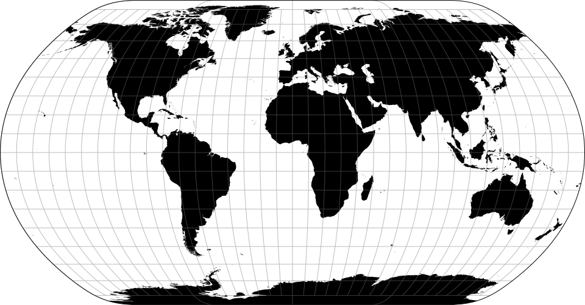

The Natural Earth projection.

###### d3.**geoNaturalEarth2**() · [Source](https://github.com/d3/d3-geo-projection/blob/main/src/naturalEarth2.js), [Examples](https://observablehq.com/@d3/natural-earth-ii) d3.**geoNaturalEarth2Raw**

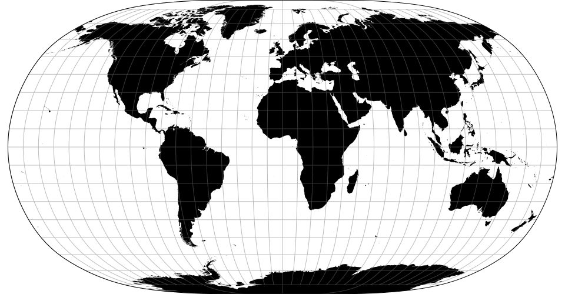

The [Natural Earth II](http://www.shadedrelief.com/NE2_proj/) projection. Compared to Natural Earth, it is slightly taller and rounder.

###### d3.**geoNellHammer**() · [Source](https://github.com/d3/d3-geo-projection/blob/main/src/nellHammer.js), [Examples](https://observablehq.com/@d3/nell-hammer) d3.**geoNellHammerRaw**

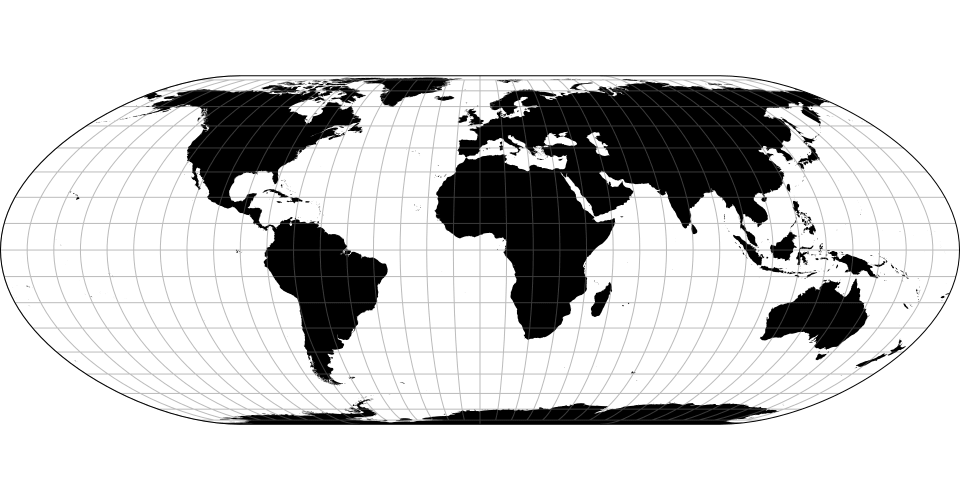

The Nell–Hammer projection.

###### d3.**geoNicolosi**() · [Source](https://github.com/d3/d3-geo-projection/blob/main/src/nicolosi.js), [Examples](https://observablehq.com/@toja/nicolosi-globular-projection) d3.**geoNicolosiRaw**

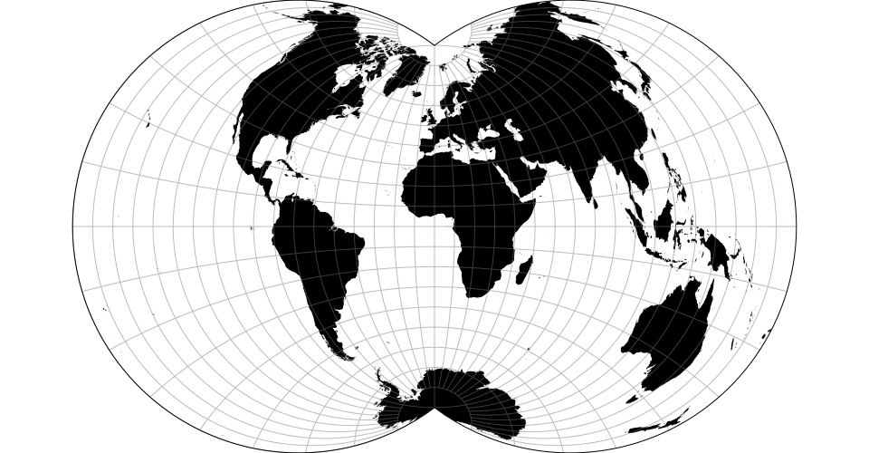

The Nicolosi globular projection.

###### d3.**geoOrthographic**() · [Source](https://github.com/d3/d3-geo/blob/main/src/projection/orthographic.js) [[d3-geo]](https://github.com/d3/d3-geo/blob/main/README.md#geoOrthographic), [Examples](https://observablehq.com/@d3/orthographic) d3.**geoOrthographicRaw**

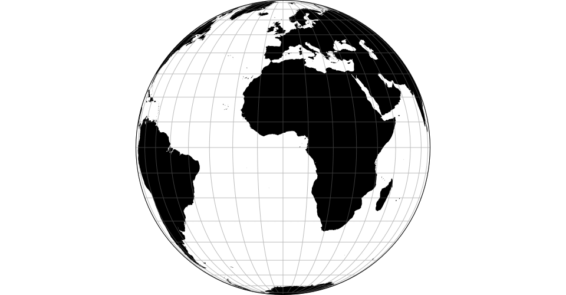

The orthographic projection.

###### d3.**geoPatterson**() · [Source](https://github.com/d3/d3-geo-projection/blob/main/src/patterson.js), [Examples](https://observablehq.com/@d3/patterson-cylindrical) d3.**geoPattersonRaw**

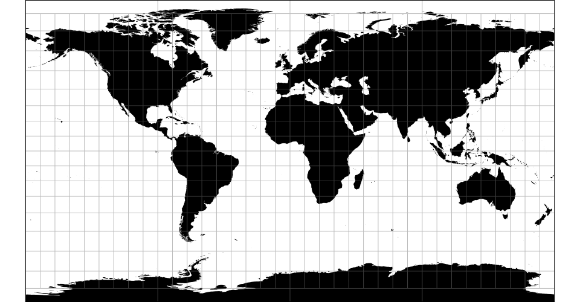

The Patterson cylindrical projection.

###### d3.**geoPolyconic**() · [Source](https://github.com/d3/d3-geo-projection/blob/main/src/polyconic.js), [Examples](https://observablehq.com/@d3/polyconic) d3.**geoPolyconicRaw**

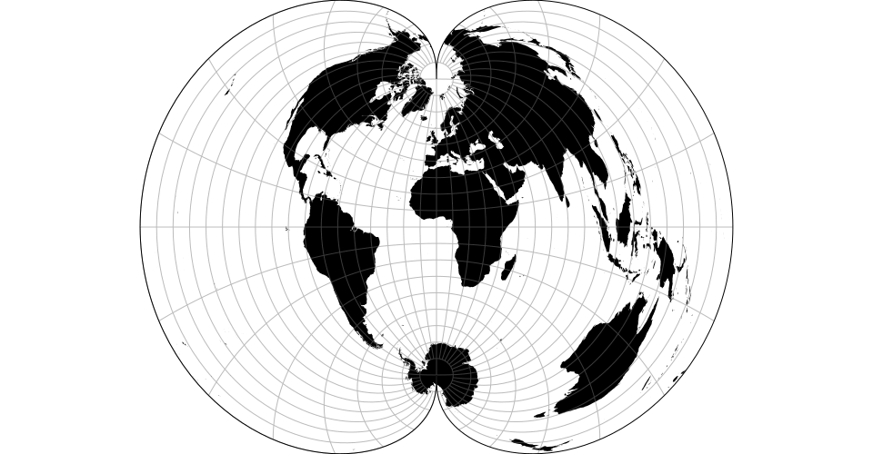

The American polyconic projection.

###### d3.**geoRectangularPolyconic**() · [Source](https://github.com/d3/d3-geo-projection/blob/main/src/rectangularPolyconic.js), [Examples](https://observablehq.com/@d3/rectangular-polyconic) d3.**geoRectangularPolyconicRaw**(*phi0*)

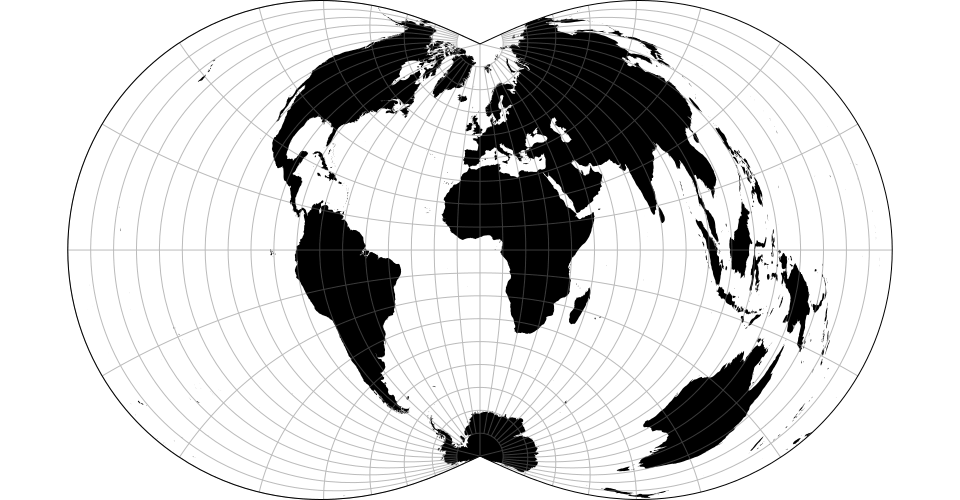

The rectangular (War Office) polyconic projection.

###### *rectangularPolyconic*.**parallel**([*parallel*])

Defaults to 0°.

###### d3.**geoRobinson**() · [Source](https://github.com/d3/d3-geo-projection/blob/main/src/robinson.js), [Examples](https://observablehq.com/@d3/robinson) d3.**geoRobinsonRaw**

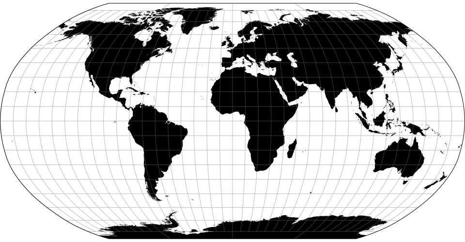

The Robinson projection.

###### d3.**geoSatellite**() · [Source](https://github.com/d3/d3-geo-projection/blob/main/src/satellite.js), [Examples](https://observablehq.com/@d3/satellite) d3.**geoSatelliteRaw**(*P*, *omega*)

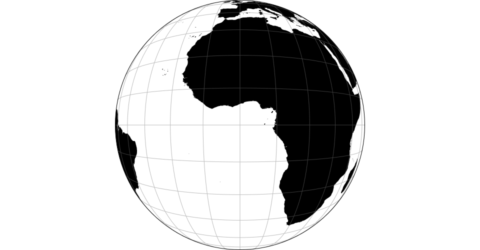

The satellite (tilted perspective) projection.

###### *satellite*.**tilt**([*tilt*])

Defaults to 0°.

###### *satellite*.**distance**([*distance*])

Distance from the center of the sphere to the point of view, as a proportion of the sphere’s radius; defaults to 2.0. The recommended maximum [clip angle](https://github.com/d3/d3-geo/blob/main/README.md#projection_clipAngle) for a given *distance* is acos(1 / *distance*) converted to degrees. If tilt is also applied, then more conservative clipping may be necessary. For exact clipping, the in-development geographic projection pipeline is needed; see the [satellite explorer](https://observablehq.com/@d3/satellite-explorer).

###### d3.**geoSinusoidal**() · [Source](https://github.com/d3/d3-geo-projection/blob/main/src/sinusoidal.js), [Examples](https://observablehq.com/@d3/sinusoidal) d3.**geoSinusoidalRaw**

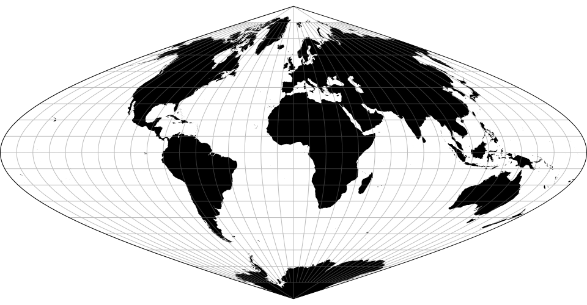

The sinusoidal projection.

###### d3.**geoSinuMollweide**() · [Source](https://github.com/d3/d3-geo-projection/blob/main/src/sinuMollweide.js), [Examples](https://observablehq.com/@d3/sinu-mollweide) d3.**geoSinuMollweideRaw**

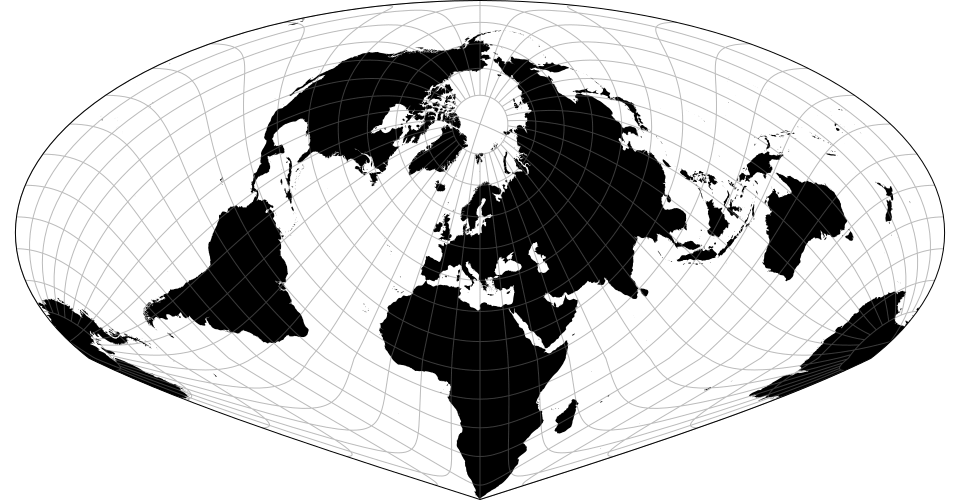

Allen K. Philbrick’s Sinu-Mollweide projection. See also the interrupted form.

###### d3.**geoStereographic**() · [Source](https://github.com/d3/d3-geo/blob/main/src/projection/stereographic.js) [[d3-geo]](https://github.com/d3/d3-geo/blob/main/README.md#geoStereographic), [Examples](https://observablehq.com/@d3/stereographic) d3.**geoStereographicRaw**

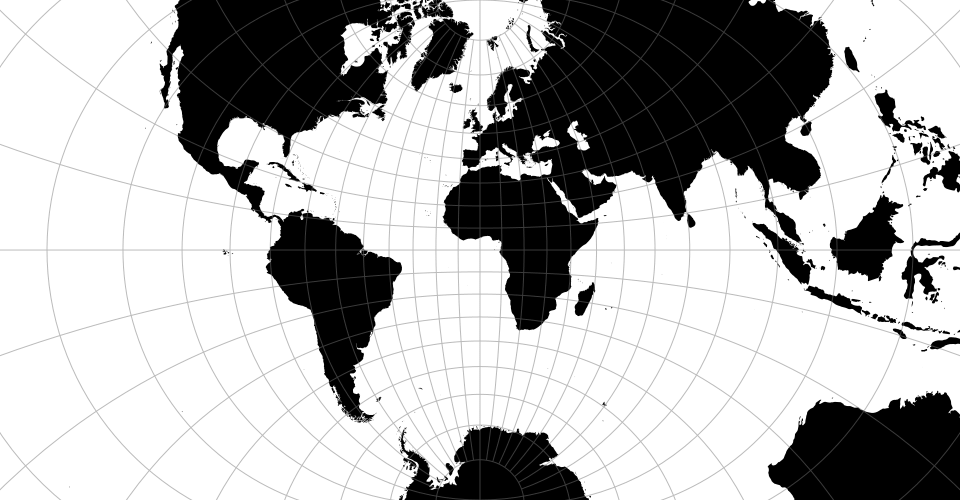

The stereographic projection.

###### d3.**geoTimes**() · [Source](https://github.com/d3/d3-geo-projection/blob/main/src/times.js), [Examples](https://observablehq.com/@d3/times) d3.**geoTimesRaw**

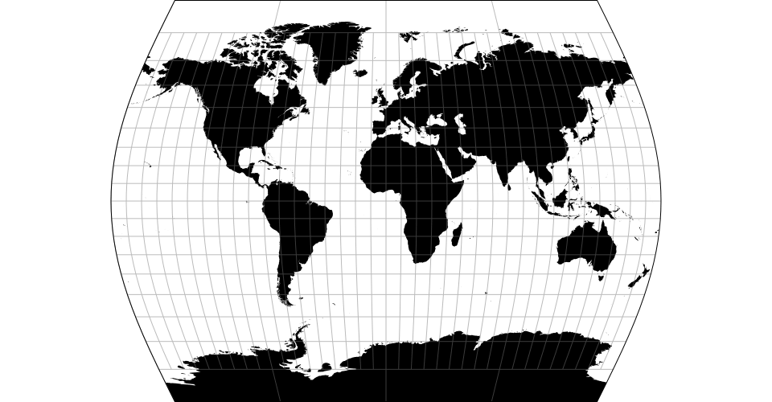

John Muir’s Times projection.

###### d3.**geoTransverseMercator**() · [Source](https://github.com/d3/d3-geo/blob/main/src/projection/transverseMercator.js) [[d3-geo]](https://github.com/d3/d3-geo/blob/main/README.md#geoTransverseMercator), [Examples](https://observablehq.com/@d3/transverse-mercator) d3.**geoTransverseMercatorRaw**

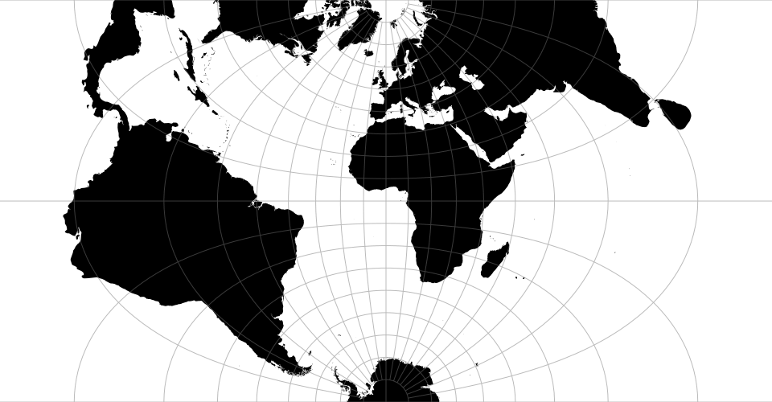

The transverse spherical Mercator projection.

###### d3.**geoTwoPointAzimuthal**(*point0*, *point1*) · [Source](https://github.com/d3/d3-geo-projection/blob/main/src/twoPointAzimuthal.js) d3.**geoTwoPointAzimuthalRaw**(*d*)

The two-point azimuthal projection “shows correct azimuths (but not distances) from either of two points to any other point. [It can] be used to locate a ship at sea, given the exact location of two radio transmitters and the direction of the ship to the transmitters.” This projection does not support [*projection*.rotate](https://github.com/d3/d3-geo/blob/main/README.md#projection_rotate), as the rotation is fixed by the two given points.

###### d3.**geoTwoPointAzimuthalUsa**() · [Source](https://github.com/d3/d3-geo-projection/blob/main/src/twoPointAzimuthal.js)

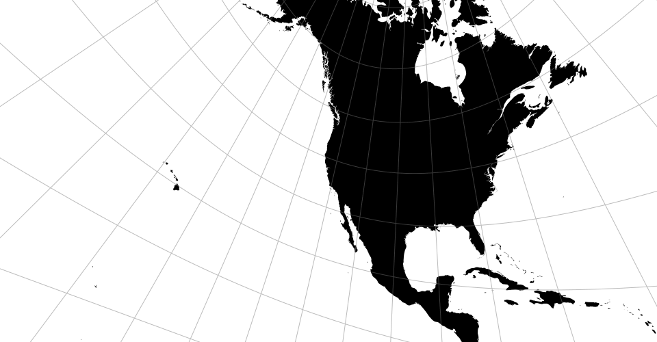

The two-point azimuthal projection with points [-158°, 21.5°] and [-77°, 39°], approximately representing Honolulu, HI and Washington, D.C.

###### d3.**geoTwoPointEquidistant**(*point0*, *point1*) · [Source](https://github.com/d3/d3-geo-projection/blob/main/src/twoPointEquidistant.js) d3.**geoTwoPointEquidistantRaw**(*z0*)

The two-point equidistant projection. This projection does not support [*projection*.rotate](https://github.com/d3/d3-geo/blob/main/README.md#projection_rotate), as the rotation is fixed by the two given points. Note: to show the whole Earth, this projection requires clipping to spherical polygons ([example](https://observablehq.com/@d3/two-point-equidistant)).

###### d3.**geoTwoPointEquidistantUsa**() · [Source](https://github.com/d3/d3-geo-projection/blob/main/src/twoPointEquidistant.js)

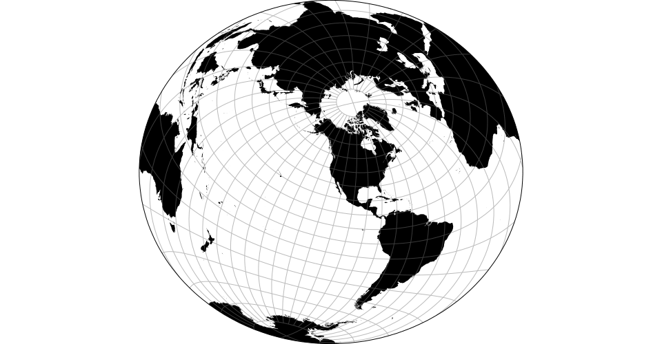

The two-point equidistant projection with points [-158°, 21.5°] and [-77°, 39°], approximately representing Honolulu, HI and Washington, D.C.

###### d3.**geoVanDerGrinten**() · [Source](https://github.com/d3/d3-geo-projection/blob/main/src/vanDerGrinten.js), [Examples](https://observablehq.com/@d3/van-der-grinten-i) d3.**geoVanDerGrintenRaw**

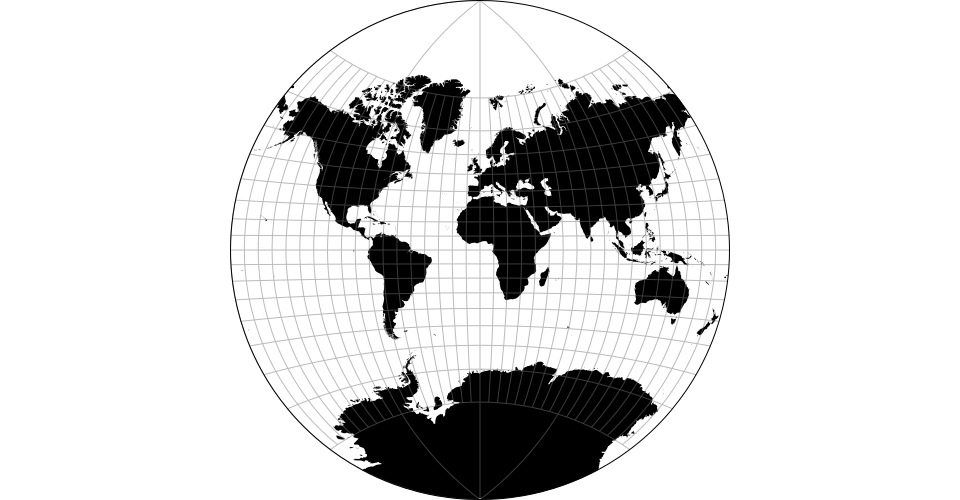

The Van der Grinten projection.

###### d3.**geoVanDerGrinten2**() · [Source](https://github.com/d3/d3-geo-projection/blob/main/src/vanDerGrinten2.js), [Examples](https://observablehq.com/@d3/van-der-grinten-ii) d3.**geoVanDerGrinten2Raw**

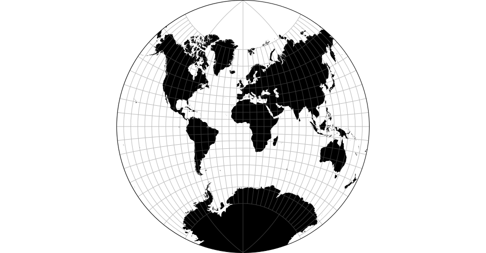

The Van der Grinten II projection.

###### d3.**geoVanDerGrinten3**() · [Source](https://github.com/d3/d3-geo-projection/blob/main/src/vanDerGrinten3.js), [Examples](https://observablehq.com/@d3/van-der-grinten-iii) d3.**geoVanDerGrinten3Raw**

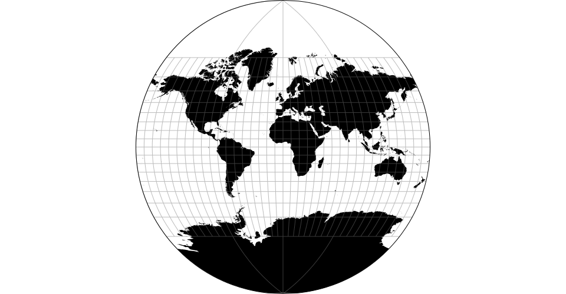

The Van der Grinten III projection.

###### d3.**geoVanDerGrinten4**() · [Source](https://github.com/d3/d3-geo-projection/blob/main/src/vanDerGrinten4.js), [Examples](https://observablehq.com/@d3/van-der-grinten-iv) d3.**geoVanDerGrinten4Raw**

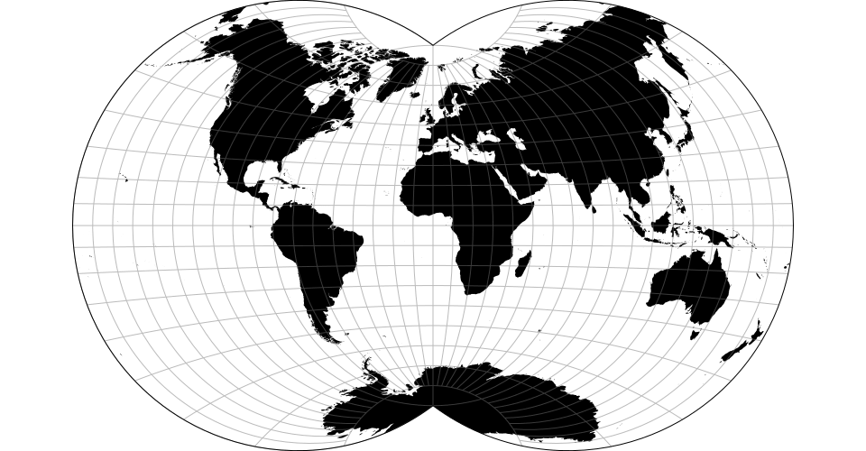

The Van der Grinten IV projection.

###### d3.**geoWagner**() · [Source](https://github.com/d3/d3-geo-projection/blob/main/src/wagner.js), [Examples](https://observablehq.com/@fil/wagner-customizable-projection) d3.**geoWagnerRaw**

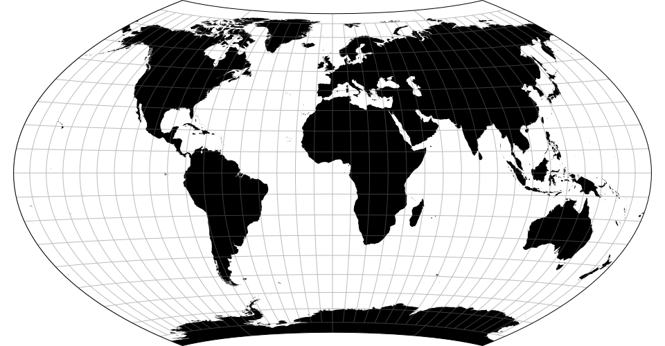

The Wagner projection is customizable: default values produce the Wagner VIII projection.

###### *wagner*.**poleline**([*poleline*])

Defaults to 65°.

###### *wagner*.**parallels**([*parallels*])

Defaults to 60°.

###### *wagner*.**inflation**([*inflation*])

Defaults to 20.

###### *wagner*.**ratio**([*ratio*])

Defaults to 200.

###### d3.**geoWagner4**() · [Source](https://github.com/d3/d3-geo-projection/blob/main/src/wagner4.js), [Examples](https://observablehq.com/@d3/wagner-iv) d3.**geoWagner4Raw**

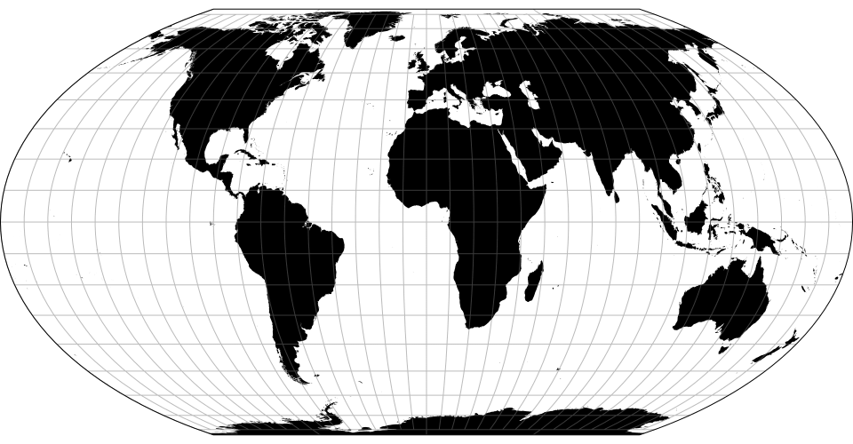

The Wagner IV projection, also known as Putniṇš P2´.

###### d3.**geoWagner6**() · [Source](https://github.com/d3/d3-geo-projection/blob/main/src/wagner6.js), [Examples](https://observablehq.com/@d3/wagner-vi) d3.**geoWagner6Raw**

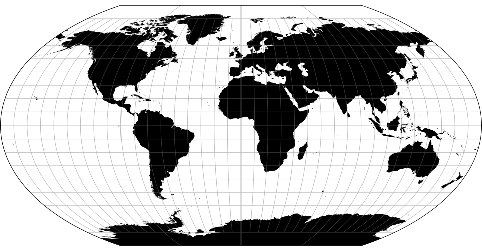

The Wagner VI projection.

###### d3.**geoWagner7**() · [Source](https://github.com/d3/d3-geo-projection/blob/main/src/wagner7.js), Examples

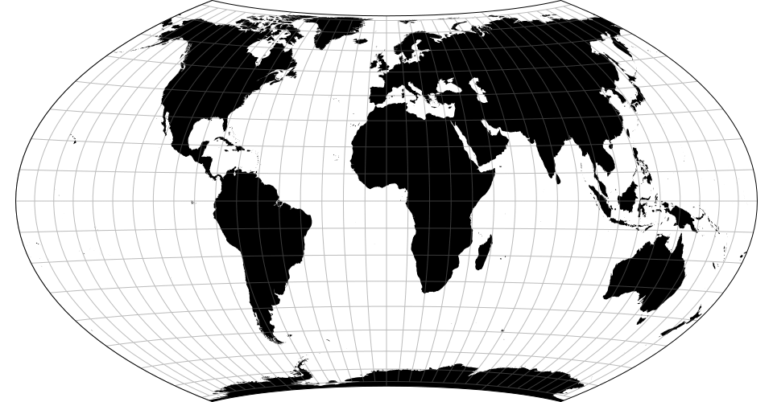

The Wagner VII projection.

###### d3.**geoWiechel**() · [Source](https://github.com/d3/d3-geo-projection/blob/main/src/wiechel.js), [Examples](https://observablehq.com/@d3/wiechel) d3.**geoWiechelRaw**

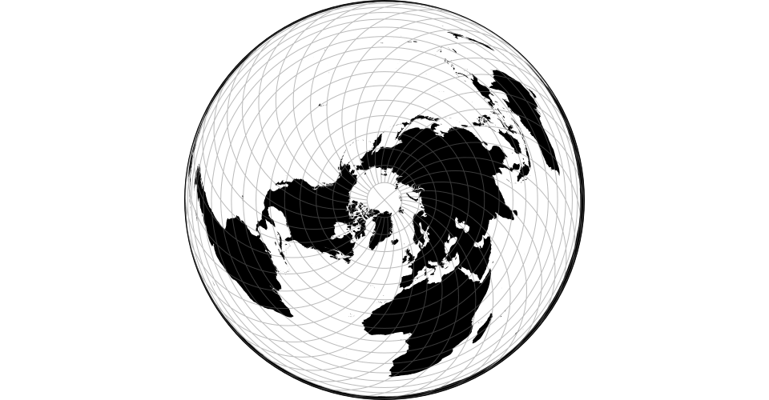

The Wiechel projection.

###### d3.**geoWinkel3**() · [Source](https://github.com/d3/d3-geo-projection/blob/main/src/winkel3.js), [Examples](https://observablehq.com/@d3/winkel-tripel) d3.**geoWinkel3Raw**

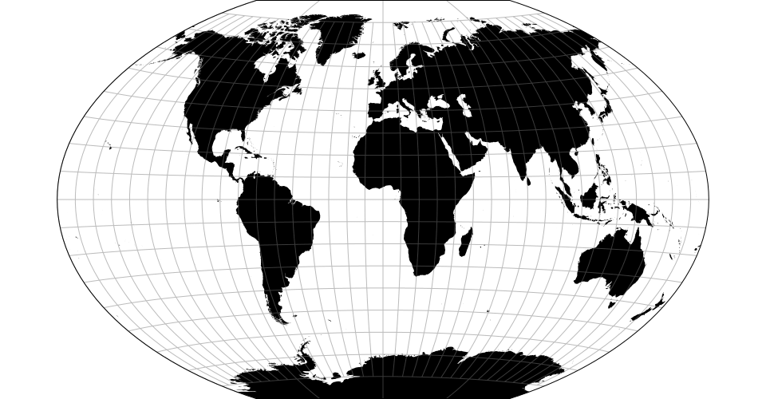

The Winkel tripel projection.

### Interrupted Projections

###### d3.**geoInterrupt**(*project*, *lobes*) · [Source](https://github.com/d3/d3-geo-projection/blob/main/src/interrupted/index.js), [Examples](https://observablehq.com/@d3/interrupted-sinusoidal)

Defines a new interrupted projection for the specified raw projection function *project* and the specified array of *lobes*. The array *lobes* contains two elements representing the hemilobes for the northern hemisphere and the southern hemisphere, respectively. Each hemilobe is an array of triangles, with each triangle represented as three points (in degrees): the start, midpoint, and end. For example, the lobes in Goode’s interrupted homolosine projection are defined as:

```
[
  [
    [[-180,   0], [-100,  90], [ -40,   0]],
    [[ -40,   0], [  30,  90], [ 180,   0]]
  ],
  [
    [[-180,   0], [-160, -90], [-100,   0]],
    [[-100,   0], [ -60, -90], [ -20,   0]],
    [[ -20,   0], [  20, -90], [  80,   0]],
    [[  80,   0], [ 140, -90], [ 180,   0]]
  ]
]
```

Note: interrupted projections typically require clipping to the sphere.

###### *interrupted*.**lobes**([*lobes*]) · [Source](https://github.com/d3/d3-geo-projection/blob/main/src/interrupted/index.js)

If *lobes* is specified, sets the new array of hemilobes and returns this projection; see d3.geoInterrupt for details on the format of the hemilobes array. If *lobes* is not specified, returns the current array of hemilobes.

###### d3.**geoInterruptedHomolosine**() · [Source](https://github.com/d3/d3-geo-projection/blob/main/src/interrupted/homolosine.js), [Examples](https://observablehq.com/@d3/interrupted-goode-homolosine)

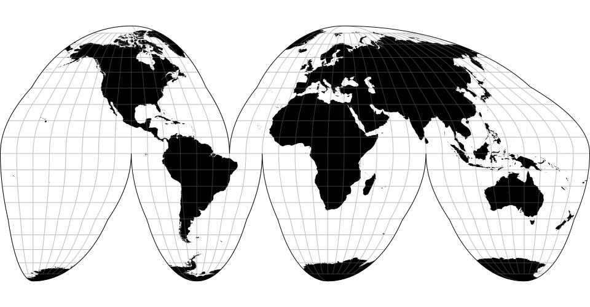

Goode’s interrupted homolosine projection. Its [ocean-centric aspect](https://observablehq.com/@d3/interrupted-homolosine-oceans) is also well-known.

###### d3.**geoInterruptedSinusoidal**() · [Source](https://github.com/d3/d3-geo-projection/blob/main/src/interrupted/sinusoidal.js), [Examples](https://observablehq.com/@d3/interrupted-sinusoidal)

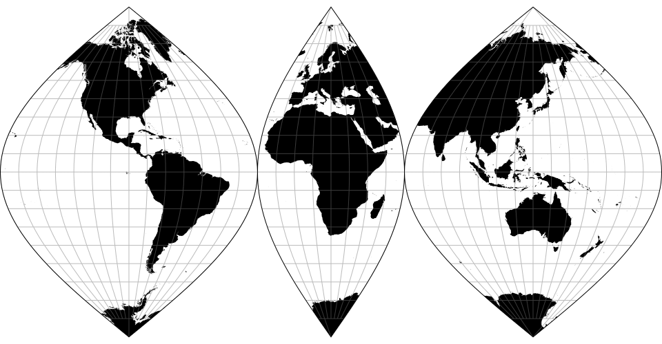

An interrupted sinusoidal projection with asymmetrical lobe boundaries that emphasize land masses over oceans, after the Swedish *Nordisk Världs Atlas* as reproduced by [C.A. Furuti](https://web.archive.org/web/20150928042327/http://www.progonos.com/furuti/MapProj/Normal/ProjInt/projInt.html#InterruptedSansonFlamsteed).

###### d3.**geoInterruptedBoggs**() · [Source](https://github.com/d3/d3-geo-projection/blob/main/src/interrupted/boggs.js), [Examples](https://observablehq.com/@d3/interrupted-boggs-eumorphic)

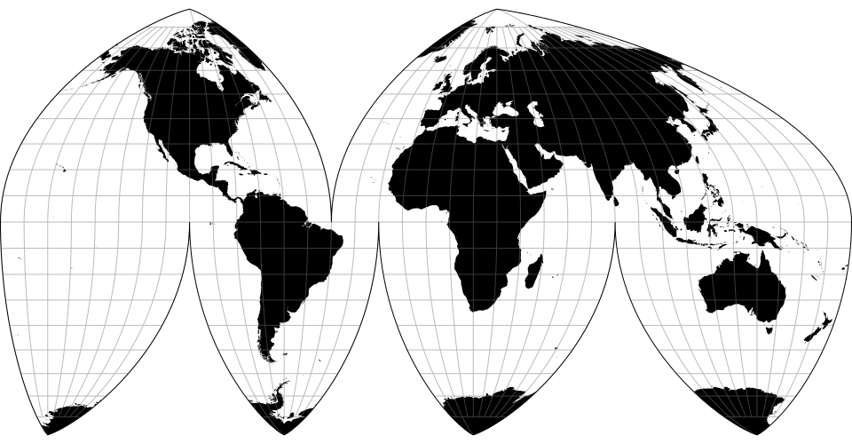

Bogg’s interrupted eumorphic projection.

###### d3.**geoInterruptedSinuMollweide**() · [Source](https://github.com/d3/d3-geo-projection/blob/main/src/interrupted/sinuMollweide.js), [Examples](https://observablehq.com/@d3/interrupted-sinu-mollweide)

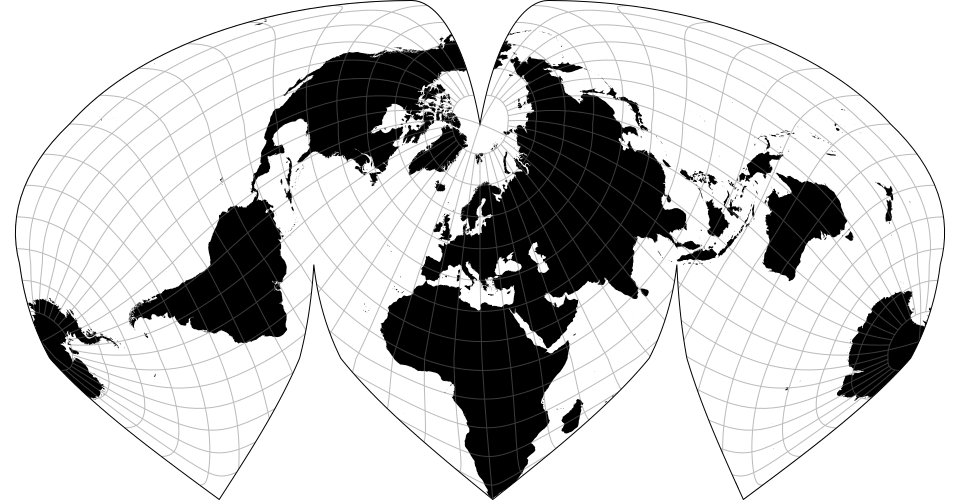

Alan K. Philbrick’s interrupted sinu-Mollweide projection.

###### d3.**geoInterruptedMollweide**() · [Source](https://github.com/d3/d3-geo-projection/blob/main/src/interrupted/mollweide.js), [Examples](https://observablehq.com/@d3/interrupted-mollweide)

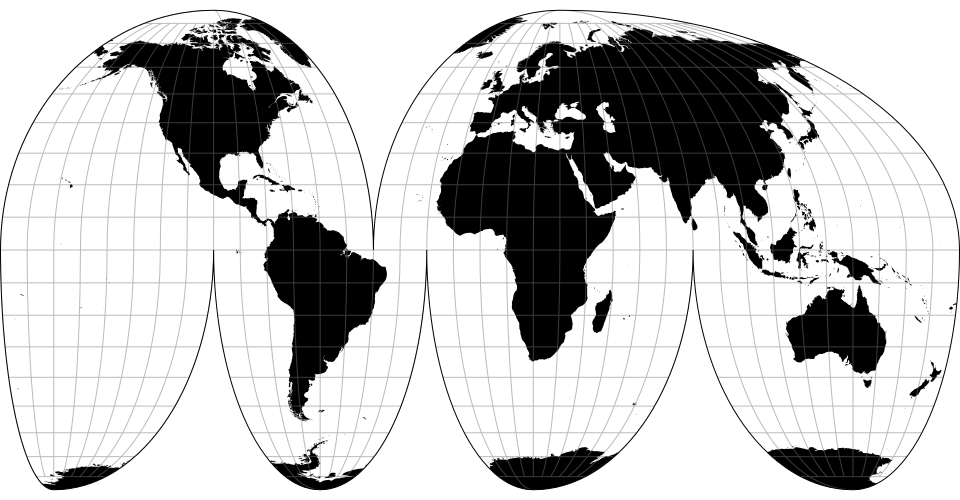

Goode’s interrupted Mollweide projection.

###### d3.**geoInterruptedMollweideHemispheres**() · [Source](https://github.com/d3/d3-geo-projection/blob/main/src/interrupted/mollweideHemispheres.js), [Examples](https://observablehq.com/@d3/mollweide-hemispheres)

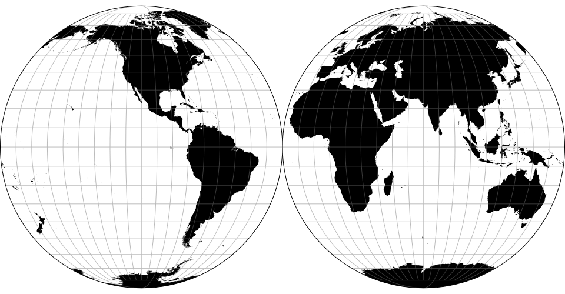

The Mollweide projection interrupted into two (equal-area) hemispheres.

###### d3.**geoInterruptedQuarticAuthalic**() · [Source](https://github.com/d3/d3-geo-projection/blob/main/src/quarticAuthalic.js), [Examples](https://observablehq.com/@piwodlaiwo/interrupted-quartic-authalic-projection)

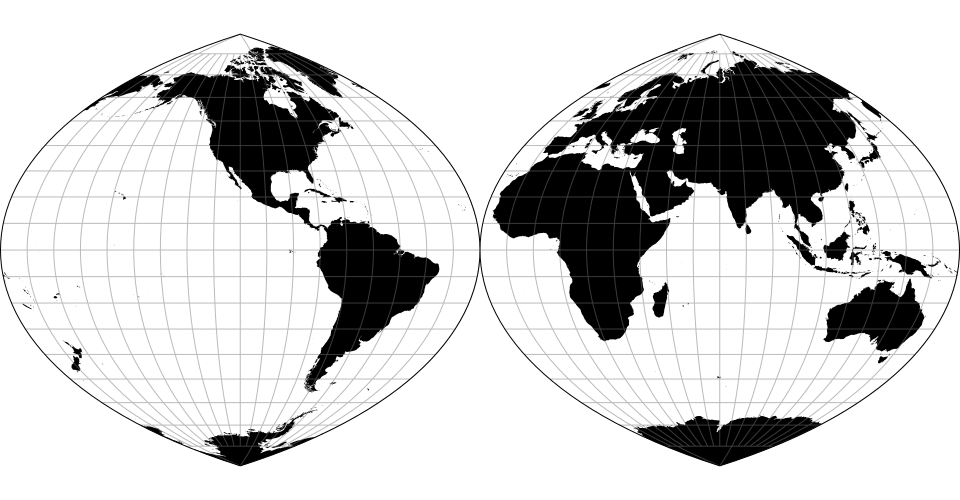

The [quartic authalic projection](https://observablehq.com/@d3/hammer?b=Infinity) interrupted into two hemispheres.

### Polyhedral Projections

###### d3.**geoPolyhedral**(*root*, *face*) · [Source](https://github.com/d3/d3-geo-projection/blob/main/src/polyhedral/index.js)

Defines a new polyhedral projection. The *root* is a spanning tree of polygon face nodes; each *node* is assigned a *node*.transform matrix. The *face* function returns the appropriate *node* for a given *lambda* and *phi* in radians. Use [*projection*.angle](https://github.com/d3/d3-geo/blob/main/README.md#projection_angle) to set the orientation of the map (the default *angle*, -30°, might change in the next major version).

###### d3.**geoPolyhedralButterfly**() · [Source](https://github.com/d3/d3-geo-projection/blob/main/src/polyhedral/butterfly.js), [Examples](https://observablehq.com/@d3/polyhedral-gnomonic)

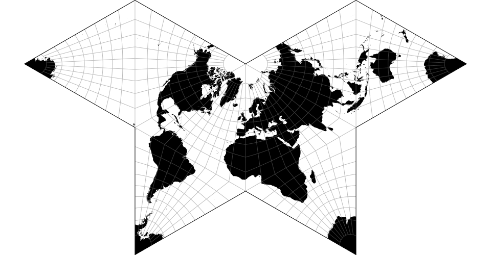

The gnomonic butterfly projection.

###### d3.**geoPolyhedralCollignon**() · [Source](https://github.com/d3/d3-geo-projection/blob/main/src/polyhedral/collignon.js), [Examples](https://observablehq.com/@d3/polyhedral-collignon)

[figure not shown]

The Collignon butterfly projection.

###### d3.**geoPolyhedralWaterman**() · [Source](https://github.com/d3/d3-geo-projection/blob/main/src/polyhedral/waterman.js), [Examples](https://observablehq.com/@d3/watermans-butterfly)

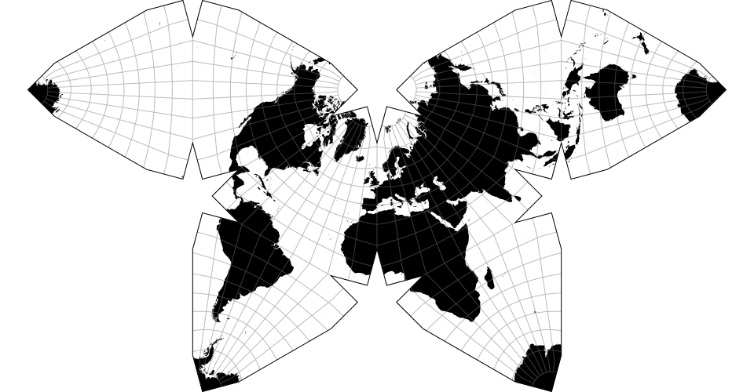

Steve Waterman’s butterfly projection.

### Quincuncial Projections

###### d3.**geoQuincuncial**(*project*) · [Source](https://github.com/d3/d3-geo-projection/blob/main/src/quincuncial/index.js)

Defines a new quincuncial projection for the specified raw projection function *project*. The default rotation is [-90°, -90°, 45°] and the default clip angle is 180° - ε.

###### d3.**geoGringortenQuincuncial**() · [Source](https://github.com/d3/d3-geo-projection/blob/main/src/quincuncial/gringorten.js)

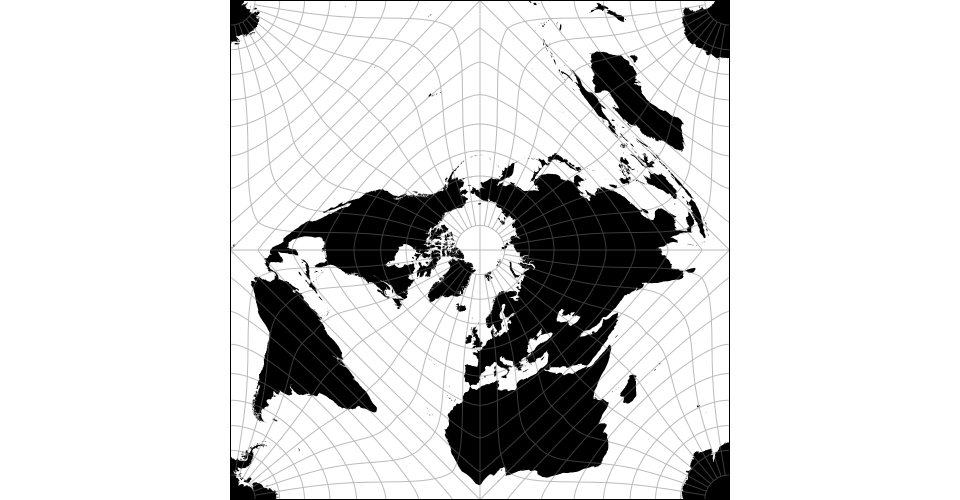

The Gringorten square equal-area projection.

###### d3.**geoPeirceQuincuncial**() · [Source](https://github.com/d3/d3-geo-projection/blob/main/src/quincuncial/peirce.js)

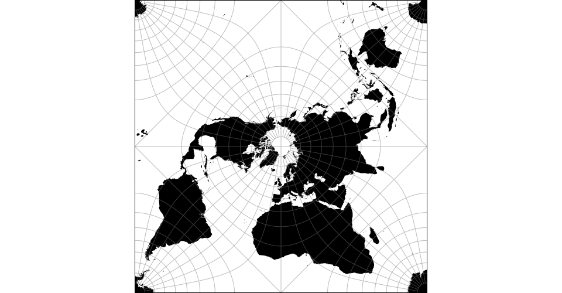

The Peirce quincuncial projection is the quincuncial form of the Guyou projection.

### Transformations

###### d3.**geoProject**(*object*, *projection*) · [Source](https://github.com/d3/d3-geo-projection/blob/main/src/project/index.js)

Projects the specified GeoJSON *object* using the specified *projection*, returning a shallow copy of the specified GeoJSON *object* with projected coordinates. Typically, the input coordinates are spherical and the output coordinates are planar, but the *projection* can also be an [arbitrary geometric transformation](https://github.com/d3/d3-geo/blob/main/README.md#transforms).

See also geoproject.

###### d3.**geoStitch**(*object*) · [Source](https://github.com/d3/d3-geo-projection/blob/main/src/stitch.js)

Returns a shallow copy of the specified GeoJSON *object*, removing antimeridian and polar cuts, and replacing straight Cartesian line segments with geodesic segments. The input *object* must have coordinates in longitude and latitude in decimal degrees per [RFC 7946](https://tools.ietf.org/html/rfc7946). [Antimeridian cutting](https://bl.ocks.org/mbostock/3788999), if needed, can then be re-applied after rotating to the desired projection aspect.

See also geostitch.

###### d3.**geoQuantize**(*object*, *digits*) · [Source](https://github.com/d3/d3-geo-projection/blob/main/src/quantize.js)

Returns a shallow copy of the specified GeoJSON *object*, rounding *x* and *y* coordinates according to [*number*.toFixed](https://developer.mozilla.org/en-US/docs/Web/JavaScript/Reference/Global_Objects/Number/toFixed). Typically this is done *after* projecting.

See also geoproject --precision and geo2svg --precision.

## Command-Line Reference

### geo2svg

###### **geo2svg** [*options…*] [*file*] · [Source](https://github.com/d3/d3-geo-projection/blob/main/bin/geo2svg)

Converts the specified GeoJSON *file* to SVG. With --newline-delimited, each input feature is rendered as a separate [path element](https://www.w3.org/TR/SVG/paths.html); otherwise, a single path element is generated.

By default, the SVG’s fill is set to none and the stroke is set to black. The default [point radius](https://github.com/d3/d3-geo/blob/main/README.md#path_pointRadius) is 4.5. To override these values on a per-feature basis, the following [GeoJSON feature](http://geojson.org/geojson-spec.html#feature-objects) properties will be propagated to attributes:

- fill
- fill-rule (or fillRule)
- fill-opacity (or fillOpacity)
- stroke
- stroke-width (or strokeWidth)
- stroke-linecap (or strokeLinecap)
- stroke-linejoin (or strokeLinejoin)
- stroke-miterlimit (or strokeMiterlimit)
- stroke-dasharray (or strokeDasharray)
- stroke-dashoffset (or strokeDashoffset)
- stroke-opacity (or strokeOpacity)
- point-radius (or pointRadius)

If the feature has an id, the path element will have a corresponding id attribute. If the feature has a *title* property, the path element will have a title element with the corresponding value. For an example of per-feature attributes, see this [California population density map](https://bl.ocks.org/mbostock/fb6c1e5ff700f9713a9dc2f0fd392c35).

Note: per-feature attributes are most useful in conjunction with newline-delimited input, as otherwise the generated SVG only has a single path element. To set these properties dynamically, pass the input through [ndjson-map](https://github.com/mbostock/ndjson-cli/blob/main/README.md#map).

###### geo2svg **-h** geo2svg **--help**

Output usage information.

###### geo2svg **-V** geo2svg **--version**

Output the version number.

###### geo2svg **-o** *file* geo2svg **--out** *file*

Specify the output file name. Defaults to “-” for stdout.

###### geo2svg **-w** *value* geo2svg **--width** *value*

Specify the output width. Defaults to 960.

###### geo2svg **-h** *value* geo2svg **--height** *value*

Specify the output height. Defaults to 500.

###### geo2svg **-p** *value* geo2svg **--precision** *value*

Reduce the precision for smaller output files. Defaults to six digits after the decimal point. See also d3.geoQuantize.

###### geo2svg **--fill** *value*

Specify the default output fill color. Defaults to none.

###### geo2svg **--stroke** *value*

Specify the default output stroke color. Defaults to black.

###### geo2svg **--r** *value* geo2svg **--radius** *value*

Specify the default output point radius. Defaults to 4.5.

###### geo2svg **-n** geo2svg **--newline-delimited**

Accept [newline-delimited JSON](http://ndjson.org/) as input, with one feature per line.

### geograticule

###### **geograticule** [*options*…] · [Source](https://github.com/d3/d3-geo-projection/blob/main/bin/geograticule)

Generates a GeoJSON graticule. See also [d3.geoGraticule](https://github.com/d3/d3-geo/blob/main/README.md#geoGraticule).

###### geograticule **-h** geograticule **--help**

Output usage information.

###### geograticule **-V** geograticule **--version**

Output the version number.

###### geograticule **-o** *file* geograticule **--out** *file*

Specify the output file name. Defaults to “-” for stdout.

###### geograticule **--extent** *value*

Sets the graticule’s extent.

###### geograticule **--extent-minor** *value*

Sets the graticule’s [minor extent](https://github.com/d3/d3-geo/blob/main/README.md#graticule_extentMinor).

###### geograticule **--extent-major** *value*

Sets the graticule’s [major extent](https://github.com/d3/d3-geo/blob/main/README.md#graticule_extentMajor).

###### geograticule **--step** *value*

Sets the graticule’s step.

###### geograticule **--step-minor** *value*

Sets the graticule’s [minor step](https://github.com/d3/d3-geo/blob/main/README.md#graticule_stepMinor).

###### geograticule **--step-major** *value*

Sets the graticule’s [major setp](https://github.com/d3/d3-geo/blob/main/README.md#graticule_stepMajor).

###### geograticule **--precision** *value*

Sets the graticule’s precision.

### geoproject

###### **geoproject** [*options*…] *projection* [*file*] · [Source](https://github.com/d3/d3-geo-projection/blob/main/bin/geoproject)

Projects the GeoJSON object in the specified input *file* using the specified *projection*, outputting a new GeoJSON *object* with projected coordinates. For example, to project standard [WGS 84](https://en.wikipedia.org/wiki/World_Geodetic_System#A_new_World_Geodetic_System:_WGS_84) input using [d3.geoAlbersUsa](https://github.com/d3/d3-geo/blob/main/README.md#geoAlbersUsa):

```
geoproject 'd3.geoAlbersUsa()' us.json \
  > us-albers.json
```

For geometry that crosses the antimeridian or surrounds a pole, you will want to pass input through geostitch first:

```
geostitch world.json \
  | geoproject 'd3.geoMercator()' \
  > world-mercator.json
```

Typically, the input coordinates are spherical and the output coordinates are planar, but the *projection* can also be an [arbitrary geometric transformation](https://github.com/d3/d3-geo/blob/main/README.md#transforms). For example, to invert the *y*-axis of a standard [spatial reference system](https://en.wikipedia.org/wiki/Spatial_reference_system) such as [California Albers (EPSG:3310)](http://spatialreference.org/ref/epsg/nad83-california-albers/) and fit it to a 960×500 viewport:

```
shp2json planar.shp \
  | geoproject 'd3.geoIdentity().reflectY(true).fitSize([960, 500], d)' \
  > planar.json
```

See also d3.geoProject and [d3.geoIdentity](https://github.com/d3/d3-geo/blob/main/README.md#geoIdentity).

###### geoproject **-h** geoproject **--help**

Output usage information.

###### geoproject **-V** geoproject **--version**

Output the version number.

###### geoproject **-o** *file* geoproject **--out** *file*

Specify the output file name. Defaults to “-” for stdout.

###### geoproject **-p** *value* geoproject **--precision** *value*

Reduce the precision for smaller output files. See also d3.geoQuantize.

###### geoproject **-n** geoproject **--newline-delimited**

Accept [newline-delimited JSON](http://ndjson.org/) as input, with one feature per line, and generate newline-delimited JSON as output.

###### geoproject **-r** *[name=]value* geoproject **--require** *[name=]value*

Requires the specified *module*, making it available for use in any expressions used by this command. The loaded module is available as the symbol *name*. If *name* is not specified, it defaults to *module*. (If *module* is not a valid identifier, you must specify a *name*.) For example, to reproject the world on the [Airocean projection](https://github.com/d3/d3-geo-polygon/blob/main/README.md#geoAirocean):

```
geoproject --require d3=d3-geo-polygon 'd3.geoAirocean()' world.geojson
```

The required *module* is resolved relative to the [current working directory](https://nodejs.org/api/process.html#process_process_cwd). If the *module* is not found during normal resolution, the [global npm root](https://docs.npmjs.com/cli/root) is also searched, allowing you to require globally-installed modules from the command line.

Multiple modules can be required by repeating this option.

### geoquantize

###### **geoquantize** [*options*…] [*file*] · [Source](https://github.com/d3/d3-geo-projection/blob/main/bin/geoquantize)

Reads the GeoJSON object from the specified input *file* and outputs a new GeoJSON *object* with coordinates reduced to *precision*. Same options as geoproject.

```
geoquantize us.json --precision 3 \
  > us-quantized.json
```

### geostitch

###### **geostitch** [*options*…] [*file*] · [Source](https://github.com/d3/d3-geo-projection/blob/main/bin/geostitch)

Stitches the GeoJSON object in the specified input *file*, removing antimeridian and polar cuts, and replacing straight Cartesian line segments with geodesic segments. The input *object* must have coordinates in longitude and latitude in decimal degrees per [RFC 7946](https://tools.ietf.org/html/rfc7946). [Antimeridian cutting](https://bl.ocks.org/mbostock/3788999), if needed, can then be re-applied after rotating to the desired projection aspect.

See geoproject for an example. See also d3.geoStitch.

###### geostitch **-h** geostitch **--help**

Output usage information.

###### geostitch **-V** geostitch **--version**

Output the version number.

###### geostitch **-o** *file* geostitch **--out** *file*

Specify the output file name. Defaults to “-” for stdout.

###### geostitch **-n** geostitch **--newline-delimited**

Accept [newline-delimited JSON](http://ndjson.org/) as input, with one feature per line, and generate newline-delimited JSON as output.

© 2010–2023 Michael Bostock  
Licensed under the BSD License.  
https://github.com/d3/d3-geo-projection